# Time Series Analysis

# Estimate the random walk model

For a given time series `y` we can fit the random walk model with a drift by first differencing the data, then fitting the white noise (WN) model to the differenced data using the `arima()` command with the `order = c(0, 0, 0))` argument.

The arima() command displays information or output about the fitted model. Under the `Coefficients:` heading is the estimated drift variable, named the `intercept`. Its approximate standard error (or s.e.) is provided directly below it. The variance of the WN part of the model is also estimated under the label `sigma^2`.

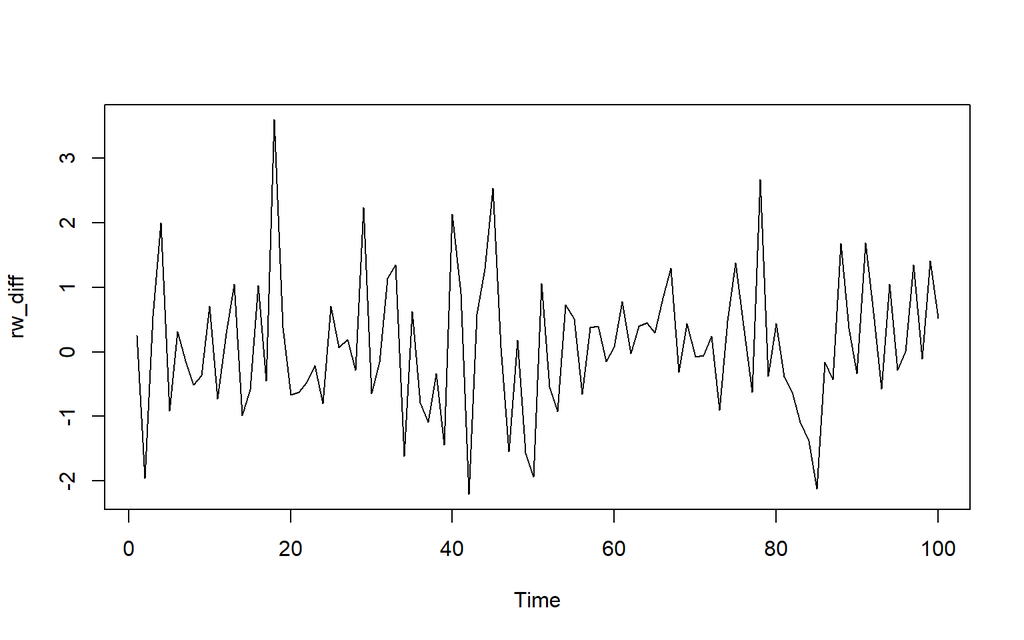

```r
# Difference your random_walk data
rw_diff <- diff(random_walk)

# Plot rw_diff
ts.plot(rw_diff)
```

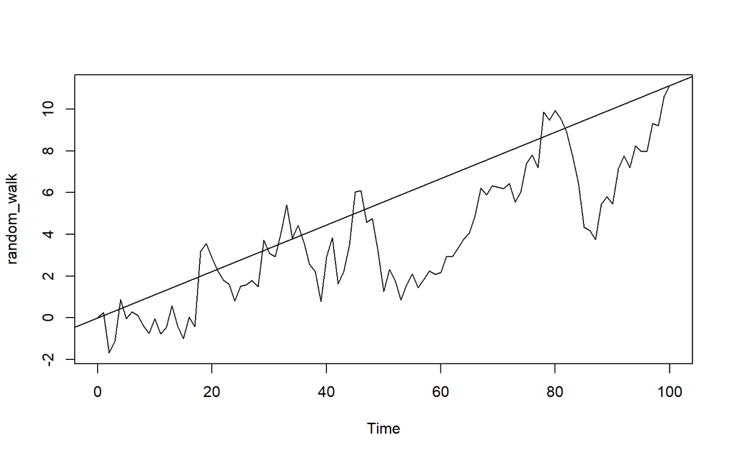

```r
# Now fit the WN model to the differenced data
model_wn <- arima(x = rw_diff, order = c(0, 0, 0))

# Store the value of the estimated time trend (intercept)
int_wn <- model_wn$coef

# Plot the original random_walk data

ts.plot(random_walk)

# Use abline(0, ...) to add time trend to the figure

abline(0, int_wn)
```

# Why stationarity matters

Stationarity makes the statistical behavior of a series stable enough for many time-series models.

For weak stationarity, focus on:

**constant mean + constant variance + covariance depending only on lag**

# Stationary Processes

**Stationarity**

- Stationary models are parsimonious.
- Stationary processes have distributional stability over time.

*Observed time series:*

- Fluctuate randomly.
- But behave similarly from one time period to the next.

**Weak stationarity**

**Weak stationary**: mean, variance, covariance constant over time.

$Y_1, Y_2, \cdots$ a weakly stationary process if:

- Mean $\mu$ of $Y_t$ is same (constant) for all $t$.
- Variance $\sigma^2$ of $Y_t$ is same (constant) for all $t$.
- Covariance of $Y_t$ and $Y_s$ is same (constant) for all $|t-s| = h,$ for all h.

$$Cov(Y_2, Y_5) = Cov(Y_7, Y_{10})$$
since each pair is separated by three units of time.

# Stationary or not?

There are many commonly encountered departures from stationarity, including time trends, periodicity, and a lack of mean reversion.

**Which of the three time series plots below appear to be from a stationary model?**

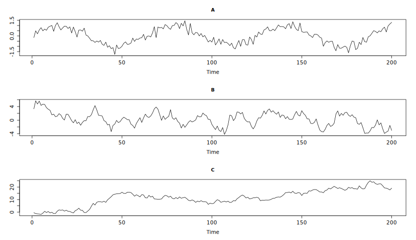

**Answer:** $\checkmark$ B.

# Are the white noise model or the random walk model stationary?

The white noise (WN) and random walk (RW) models are very closely related. However, only the RW is always non-stationary, both with and without a drift term. This is a simulation exercise to highlight the differences.

Recall that if we start with a mean zero WN process and compute its running or cumulative sum, the result is a RW process. The `cumsum()` function will make this transformation for you. Similarly, if we create a WN process, but change its mean from zero, and then compute its cumulative sum, the result is a RW process with a drift.

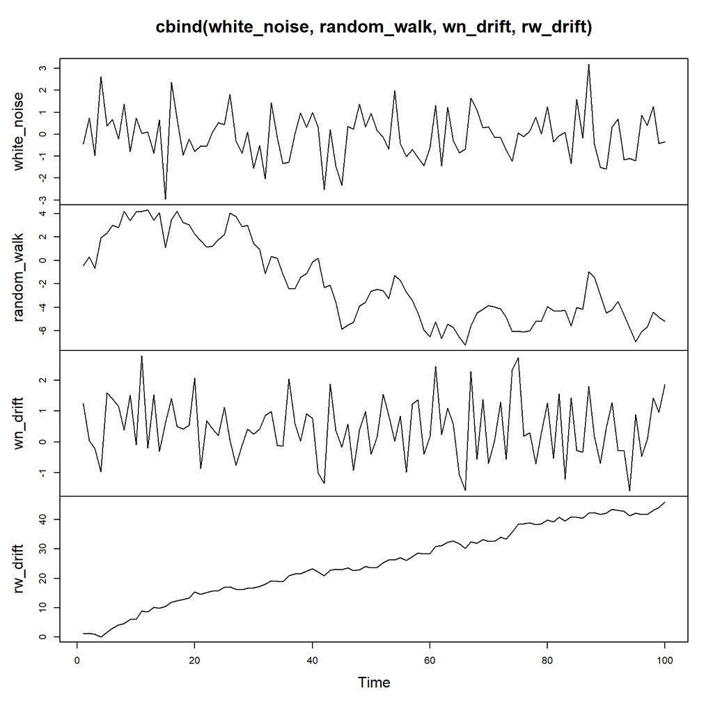

```r
# Use arima.sim() to generate WN data
white_noise <- arima.sim(model = list(order = c(0, 0, 0)), n = 100)

# Use cumsum() to convert your WN data to RW
random_walk <- cumsum(white_noise)

# Use arima.sim() to generate WN drift data
wn_drift <- arima.sim(model = list(order = c(0, 0, 0)), n = 100, mean = 0.4)

# Use cumsum() to convert your WN drift data to RW
rw_drift <- cumsum(wn_drift)

# Plot all four data objects
plot.ts(cbind(white_noise, random_walk, wn_drift, rw_drift))
```

# Dependence is the central idea

Two related concepts:

- **Correlation:** dependence between two different variables at the same time.
- **Autocorrelation:** dependence between a series and its own past.

> **Rule of thumb:** Prices can look highly correlated because of shared trends; returns often give a clearer picture of short-run dependence.

# Correlation analysis and the autocorrelation function

# Scatterplot

**Asset prices vs. asset returns**

The goal of investing is to make a profit. The revenue or loss from investing depends on the amount invested and changes in prices, and high revenue relative to the size of an investment is of central interest. This is what financial asset returns measure, changes in price as a fraction of the initial price over a given time horizon, for example, one business day.

Let’s again consider the `eu_stocks` dataset. This dataset reports index values, which we can regard as prices. The indices are not investable assets themselves, but there are many investable financial assets that closely track major market indices, including mutual funds and exchange traded funds.

Log returns, also called continuously compounded returns, are also commonly used in financial time series analysis. They are the log of gross returns, or equivalently, the changes (or first differences) in the logarithm of prices.

The change in appearance between daily prices and daily returns is typically substantial, while the difference between daily returns and log returns is usually small. As you’ll see later, one advantage of using log returns is that calculating multi-period returns from individual periods is greatly simplified - you just add them together!

In this exercise, you’ll further explore the `eu_stocks` dataset, including plotting prices, converting prices to (net) returns, and converting prices to log returns.

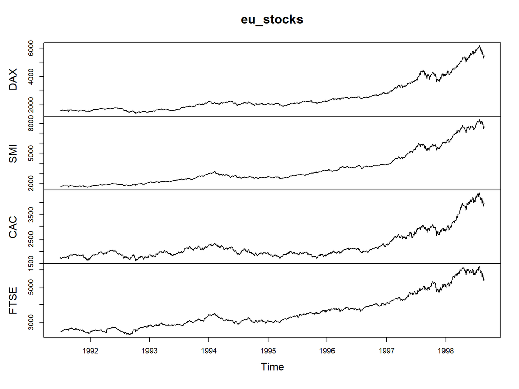

```r
# Plot eu_stocks
plot(eu_stocks)
```

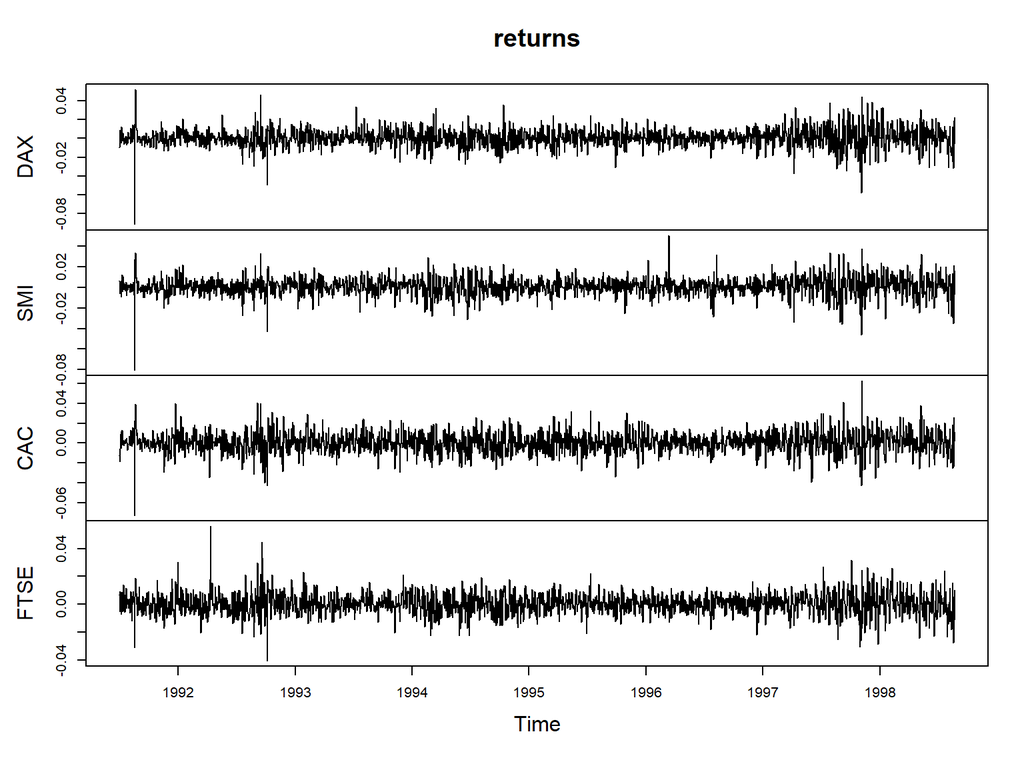

```r
# Use this code to convert prices to returns
returns <- eu_stocks[-1,] / eu_stocks[-1860,] - 1

# Convert returns to ts
returns <- ts(returns, start = c(1991, 130), frequency = 260)

# Plot returns
plot(returns)
```

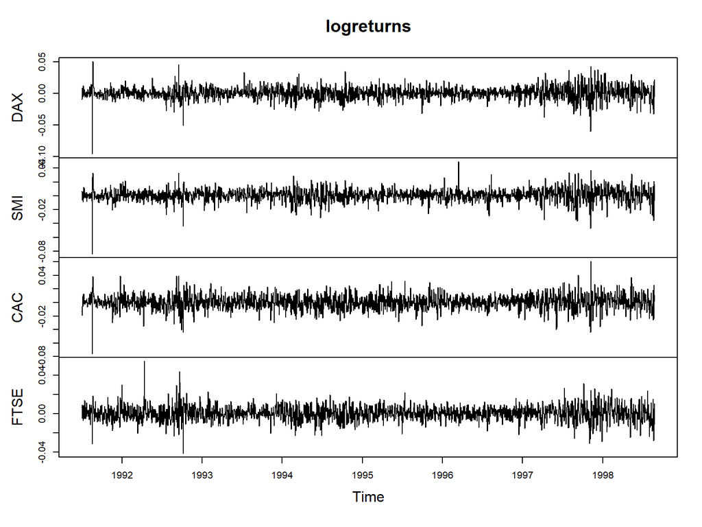

```r
# Use this code to convert prices to log returns
logreturns <- diff(log(eu_stocks))

# Plot logreturns
plot(logreturns)
```

# Characteristics of financial time series

Daily financial asset returns typically share many characteristics. Returns over one day are typically small, and their average is close to zero. At the same time, their variances and standard deviations can be relatively large. Over the course of a few years, several very large returns (in magnitude) are typically observed. These relative outliers happen on only a handful of days, but they account for the most substantial movements in asset prices. Because of these extreme returns, the distribution of daily asset returns is not normal, but heavy-tailed, and sometimes skewed. In general, individual stock returns typically have even greater variability and more extreme observations than index returns.

In this exercise, you’ll work with the `eu_percentreturns` dataset, which is the percentage returns calculated from your `eu_stocks` data. For each of the four indices contained in your data, you’ll calculate the sample mean, variance, and standard deviation.

Notice that the average daily return is about 0, while the standard deviation is about 1 percentage point. Also apply the hist() and qqnorm() functions to make histograms and normal quantile plots, respectively, for each of the indices.

```r
eu_percentreturns <- returns*100

# Generate means from eu_percentreturns
colMeans(eu_percentreturns)
```

```
##        DAX        SMI        CAC       FTSE
## 0.07052174 0.08609470 0.04979471 0.04637479
```

```r
# Use apply to calculate sample variance from eu_percentreturns
apply(eu_percentreturns, MARGIN = 2, FUN = var)
```

```
##       DAX       SMI       CAC      FTSE
## 1.0569648 0.8523711 1.2159091 0.6344767
```

```r
# Use apply to calculate standard deviation from eu_percentreturns
apply(eu_percentreturns, MARGIN = 2, FUN = sd)
```

```
##       DAX       SMI       CAC      FTSE
## 1.0280879 0.9232394 1.1026827 0.7965405
```

# Plotting pairs of data

Time series data is often presented in a time series plot. For example, the index values from the `eu_stocks` dataset are shown in the adjoining figure. Recall, `eu_stocks` contains daily closing prices from 1991-1998 for the major stock indices in Germany (`DAX`), Switzerland (`SMI`), France (`CAC`), and the UK (`FTSE`).

It is also useful to examine the bivariate relationship between pairs of time series. In this exercise we will consider the contemporaneous relationship, that is matching observations that occur at the same time, between pairs of index values as well as their log returns. The `plot(a, b)` function will produce a scatterplot when two time series names `a` and `b` are given as input.

To simultaneously make scatterplots for all pairs of several assets the `pairs()` function can be applied to produce a scatterplot matrix. When shared time trends are present in prices or index values it is common to instead compare their returns or log returns.

In this exercise, you’ll practice these skills on the `eu_stocks` data. Because the `DAX` and `FTSE` returns have similar time coverage, you can easily make a scatterplot of these indices. Note that the normal distribution has elliptical contours of equal probability, and pairs of data drawn from the multivariate normal distribution form a roughly elliptically shaped point cloud. Do any of the pairs in the scatterplot matrices exhibit this pattern, before or after log transformation?

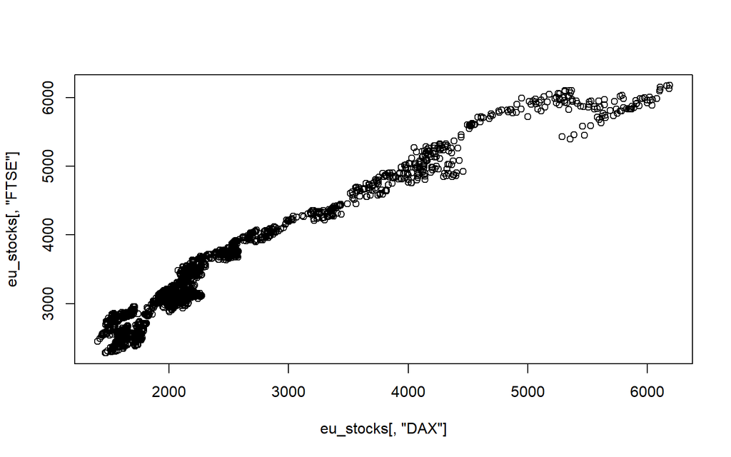

```r
# Make a scatterplot of DAX and FTSE
plot(eu_stocks[, "DAX"], eu_stocks[, "FTSE"])
```

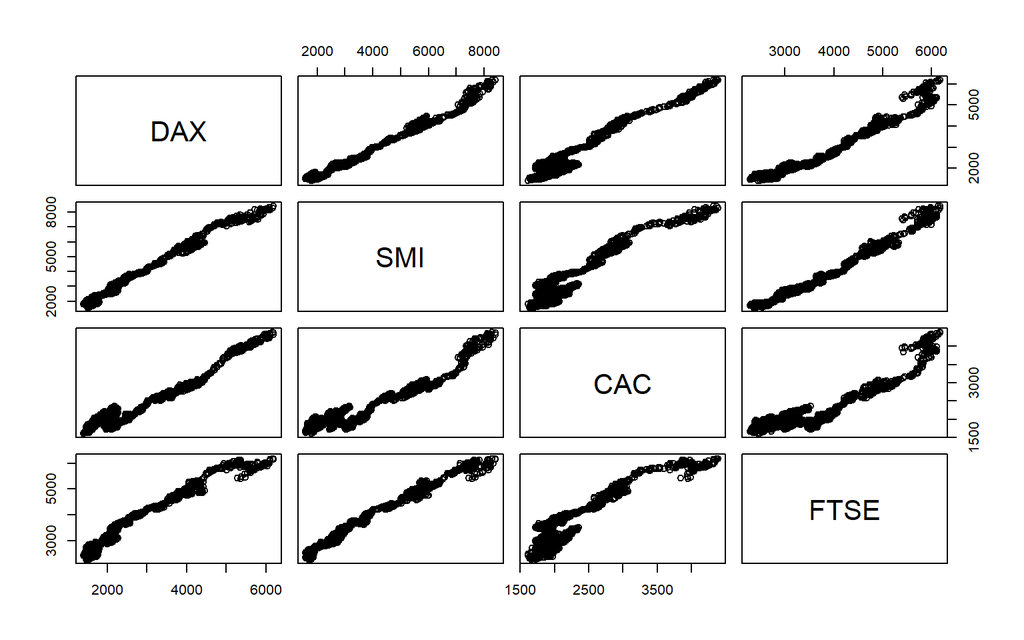

```r
# Make a scatterplot matrix of eu_stocks
pairs(eu_stocks)
```

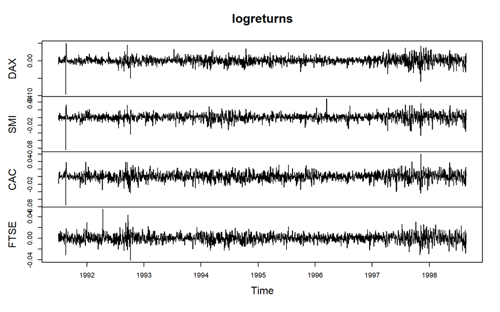

```r
# Convert eu_stocks to log returns
logreturns <- diff(log(eu_stocks))

# Plot logreturns
plot(logreturns)
```

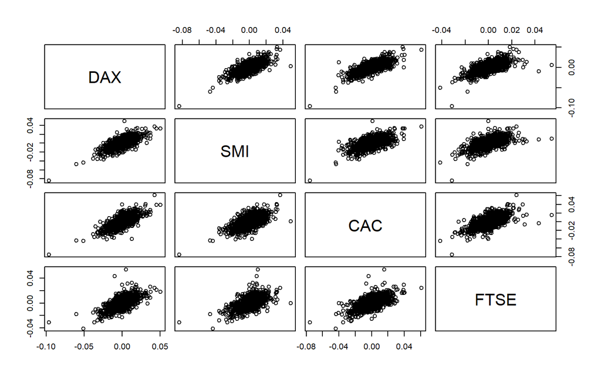

```r
# Make a scatterplot matrix of logreturns

pairs(logreturns)
```

# Covariance and Correlation

# Calculating sample covariances and correlations

Sample covariances measure the strength of the linear relationship between matched pairs of variables. The `cov()` function can be used to calculate covariances for a pair of variables, or a covariance matrix when a matrix containing several variables is given as input. For the latter case, the matrix is symmetric with covariances between variables on the off-diagonal and variances of the variables along the diagonal. On the right you can see the scatterplot matrix of your `logreturns` data.

Covariances are very important throughout finance, but they are not scale free and they can be difficult to directly interpret. Correlation is the standardized version of covariance that ranges in value from -1 to 1, where values close to 1 in magnitude indicate a strong linear relationship between pairs of variables. The `cor()` function can be applied to both pairs of variables as well as a matrix containing several variables, and the output is interpreted analogously.

```r
# Use cov() with DAX_logreturns and FTSE_logreturns
cov(logreturns[, "DAX"], logreturns[, "FTSE"])
```

```
## [1] 5.241794e-05
```

```r
# Use cov() with logreturns
cov(logreturns)
```

```
##               DAX          SMI          CAC         FTSE
## DAX  1.061072e-04 6.699564e-05 8.345130e-05 5.241794e-05
## SMI  6.699564e-05 8.556317e-05 6.285881e-05 4.304517e-05
## CAC  8.345130e-05 6.285881e-05 1.216802e-04 5.693174e-05
## FTSE 5.241794e-05 4.304517e-05 5.693174e-05 6.332543e-05
```

```r
# Use cor() with DAX_logreturns and FTSE_logreturns
cov(logreturns[, "DAX"], logreturns[, "FTSE"])
```

```
## [1] 5.241794e-05
```

```r
# Use cor() with logreturns
cor(logreturns)
```

```
##            DAX       SMI       CAC      FTSE
## DAX  1.0000000 0.7031219 0.7344304 0.6394674
## SMI  0.7031219 1.0000000 0.6160454 0.5847791
## CAC  0.7344304 0.6160454 1.0000000 0.6485679
## FTSE 0.6394674 0.5847791 0.6485679 1.0000000
```

### Guess the correlation coefficient

**Which scatterplot has a sample correlation of approximately `0.90`?**

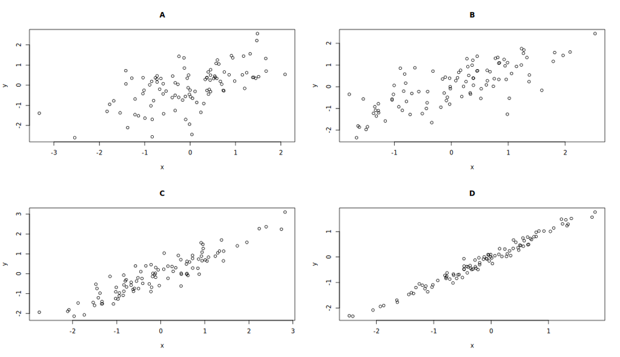

**Answer:** $\checkmark$ C.

# Autocorrelation

# Calculating autocorrelations

Autocorrelations or lagged correlations are used to assess whether a time series is dependent on its past. For a time series `x` of length `n` we consider the `n-1` pairs of observations one time unit apart. The first such pair is `(x[2],x[1])`, and the next is `(x[3],x[2])`. Each such pair is of the form `(x[t],x[t-1])` where t is the observation index, which we vary from 2 to n in this case. The lag-1 autocorrelation of `x` can be estimated as the sample correlation of these `(x[t], x[t-1])` pairs.

In general, we can manually create these pairs of observations. First, create two vectors, `x_t0` and `x_t1`, each with length `n-1`, such that the rows correspond to `(x[t], x[t-1])` pairs. Then apply the `cor()` function to estimate the lag-1 autocorrelation.

Luckily, the `acf()` command provides a shortcut. Applying `acf(..., lag.max = 1, plot = FALSE)` to a series x automatically calculates the lag-1 autocorrelation.

Finally, note that the two estimates differ slightly as they use slightly different scalings in their calculation of sample covariance, `1/(n-1)` versus `1/n`. Although the latter would provide a biased estimate, it is preferred in time series analysis, and the resulting autocorrelation estimates only differ by a factor of `(n-1)/n`.

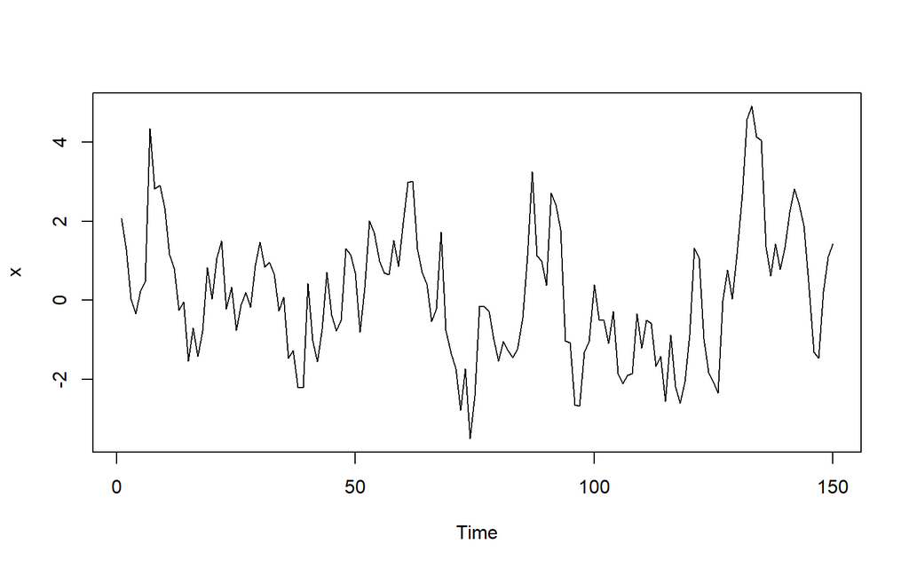

```r
x <- c(
  2.06554379, 1.29963803, 0.03357800, -0.34258065, 0.23256126, 0.46812008,
  4.34111562, 2.82007636, 2.90799984, 2.33495061, 1.15989954, 0.82008659,
  -0.24338927, -0.03355907, -1.53548216, -0.69363797, -1.41731648, -0.76623179,
  0.83536060, 0.04395345, 1.07447506, 1.50200360, -0.21238609, 0.32996521,
  -0.75033470, -0.10522038, 0.20471918, -0.17170595, 0.87181378, 1.47213721,
  0.84112591, 0.96430157, 0.66829027, -0.25752691, 0.08193916, -1.46057000,
  -1.26726830, -2.19329186, -2.21008902, 0.42338945, -1.01513893, -1.54446229,
  -0.72524036, 0.70352378, -0.36108456, -0.77422092, -0.50023603, 1.31369378,
  1.15621723, 0.68782375, -0.79475183, 0.32563325, 2.00955556, 1.70614293,
  0.99910640, 0.68932712, 0.65764259, 1.51403467, 0.85806413, 1.96951273,
  2.98268339, 3.01781322, 1.30009671, 0.71140225, 0.40782908, -0.53429804,
  -0.21147251, 1.72814428, -0.75541665, -1.34178777, -1.72317007, -2.78147841,
  -1.72572507, -3.49466071, -2.41789449, -0.13744248, -0.15805310, -0.27865357,
  -0.97493500, -1.52666608, -1.04093146, -1.26059748, -1.44067012, -1.23902633,
  -0.44668174, 1.12562870, 3.25518488, 1.13570549, 0.98992411, 0.38244269,
  2.71124649, 2.42216865, 1.78509981, -1.03092109, -1.06607323, -2.63465306,
  -2.66808169, -1.30411399, -1.04269885, 0.40215260, -0.48928251, -0.49381470,
  -1.08457733, -0.27456945, -1.84390881, -2.09907629, -1.88923578, -1.84534263,
  -0.33812159, -1.20911695, -0.50157701, -0.58298734, -1.66575871, -1.41327839,
  -2.55380296, -0.86895290, -2.16915012, -2.60202618, -2.05678159, -0.87654110,
  1.32919650, 1.07620974, -0.96432698, -1.81480027, -2.05757608, -2.34353353,
  -0.01467163, 0.77321454, 0.03106214, 1.16999559, 2.67732293, 4.57761736,
  4.90582958, 4.13300371, 4.04398099, 1.35081333, 0.61429043, 1.42969023,
  0.79231154, 1.34178061, 2.22016551, 2.82502290, 2.43279283, 1.89023418,
  0.46877402, -1.30680558, -1.45910588, 0.21169330, 1.10203354, 1.42360646
)

x <- ts(data = x, start = c(1, 1), frequency = 1)

ts.plot(x)
```

```r
n <- length(x)

# Define x_t0 as x[-1]
x_t0 <- x[-1]

# Define x_t1 as x[-n]
x_t1 <- x[-n]

# Confirm that x_t0 and x_t1 are (x[t], x[t-1]) pairs
head(cbind(x_t0, x_t1))
```

```
##            x_t0       x_t1
## [1,]  1.2996380  2.0655438
## [2,]  0.0335780  1.2996380
## [3,] -0.3425806  0.0335780
## [4,]  0.2325613 -0.3425806
## [5,]  0.4681201  0.2325613
## [6,]  4.3411156  0.4681201
```

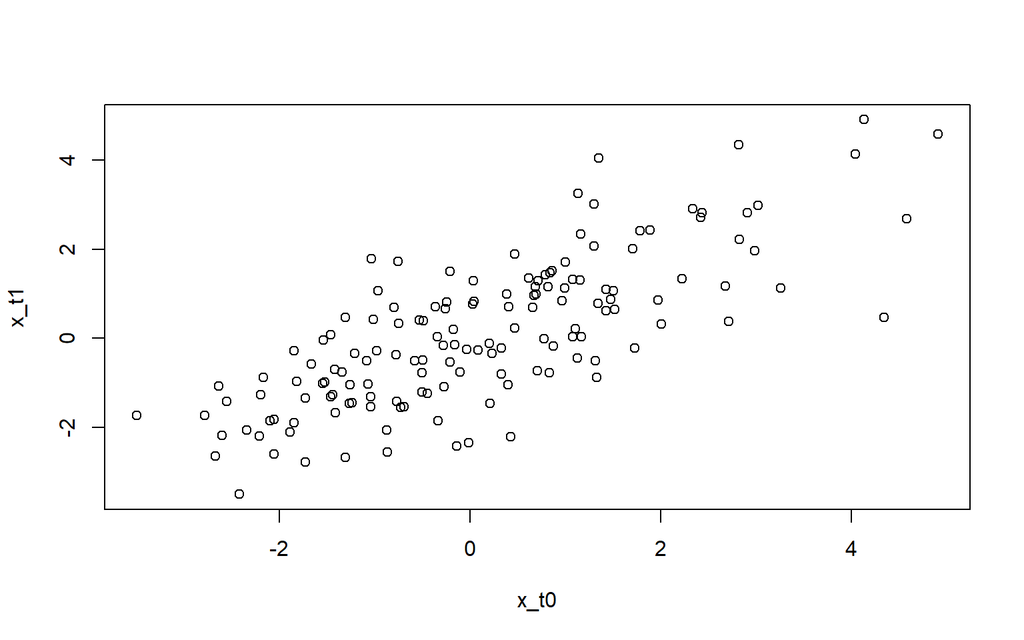

```r
# Plot x_t0 and x_t1
plot(x_t0, x_t1)
```

```r
# View the correlation between x_t0 and x_t1
cor(x_t0, x_t1)
```

```
## [1] 0.7630314
```

```r
# Use acf with x
acf(x, lag.max = 1, plot = FALSE)
```

```
##
## Autocorrelations of series 'x', by lag
##
##     0     1
## 1.000 0.758
```

```r
# Confirm that difference factor is (n-1)/n
cor(x_t1, x_t0) * (n-1)/n
```

```
## [1] 0.7579445
```

# The autocorrelation function

Autocorrelations can be estimated at many lags to better assess how a time series relates to its past. We are typically most interested in how a series relates to its most recent past.

The

`acf(..., lag.max = ..., plot = FALSE)`

function will estimate all autocorrelations from 0, 1, 2,…, up to the value specified by the argument `lag.max`. In the previous exercise, you focused on the lag-1 autocorrelation by setting the `lag.max` argument to `1`.

```r
# Generate ACF estimates for x up to lag-10
acf(x, lag.max = 10, plot = FALSE)
```

```
##
## Autocorrelations of series 'x', by lag
##
##     0     1     2     3     4     5     6     7     8     9    10
## 1.000 0.758 0.537 0.345 0.227 0.198 0.140 0.114 0.124 0.118 0.100
```

# Visualizing the autocorrelation function

Estimating the autocorrelation function (ACF) at many lags allows us to assess how a time series `x` relates to its past. The numeric estimates are important for detailed calculations, but it is also useful to visualize the ACF as a function of the lag.

In fact, the `acf()` command produces a figure by default. It also makes a default choice for `lag.max`, the maximum number of lags to be displayed.

Three time series `x`, `y`, and `z` have been loaded into your R environment and are plotted on the right. The time series `x` shows strong persistence, meaning the current value is closely relatively to those that proceed it. The time series `y` shows a periodic pattern with a cycle length of approximately four observations, meaning the current value is relatively close to the observation four before it. The time series `z` does not exhibit any clear pattern.

In this exercise, you’ll plot an estimated autocorrelation function for each time series. In the plots produced by `acf()`, the lag for each autocorrelation estimate is denoted on the horizontal axis and each autocorrelation estimate is indicated by the height of the vertical bars. Recall that the ACF at lag-0 is always 1.

Finally, each ACF figure includes a pair of blue, horizontal, dashed lines representing lag-wise 95% confidence intervals centered at zero. These are used for determining the statistical significance of an individual autocorrelation estimate at a given lag versus a null value of zero, i.e., no autocorrelation at that lag.

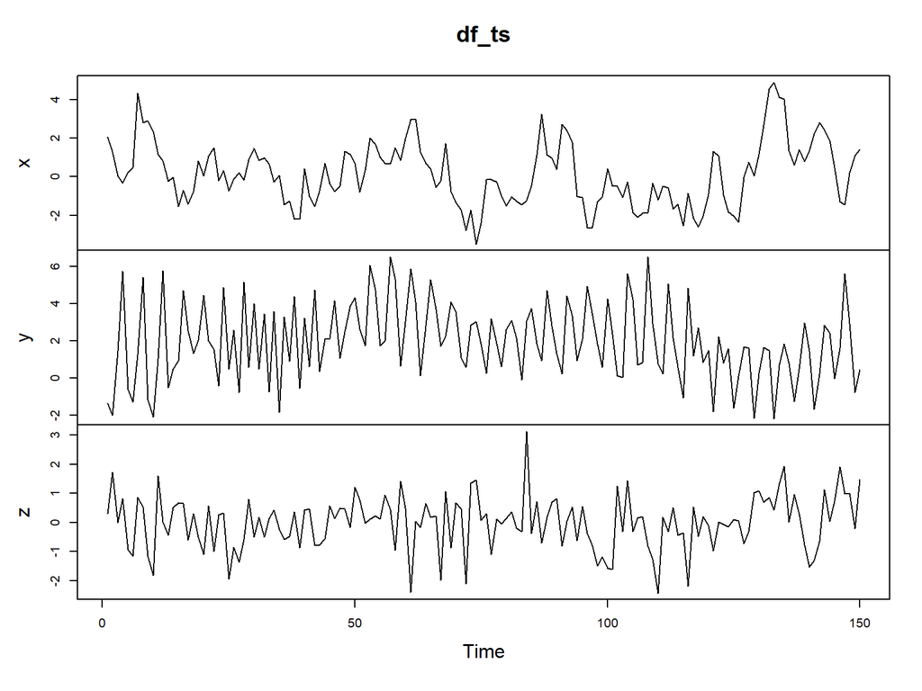

```r
df <- read.table("x_y_z_three_columns.txt", header = T)

df_ts <- ts(data = df, start = c(1, 1), frequency = 1)

plot(df_ts)
```

```r
x <- df_ts[, "x"]
y <- df_ts[, "y"]
z <- df_ts[, "z"]
```

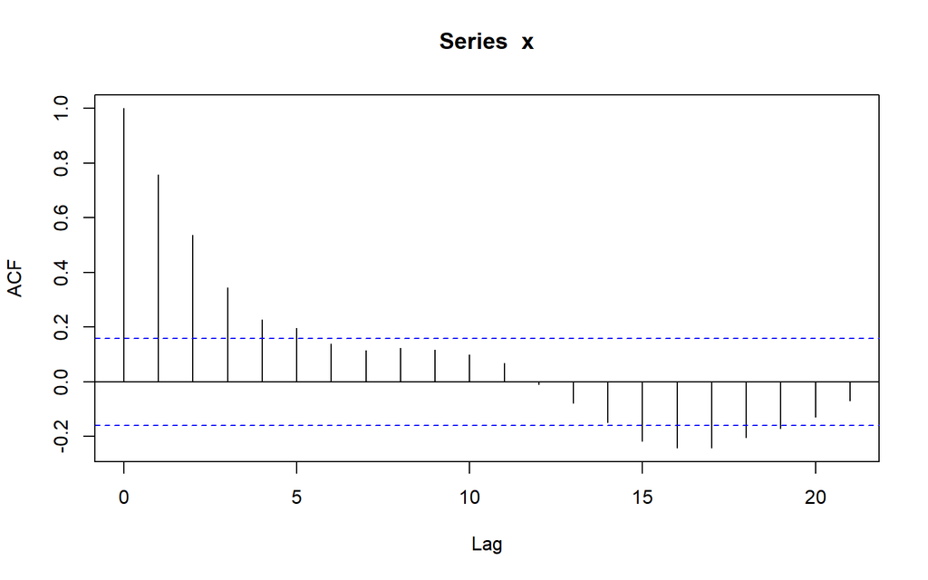

```r
# View the ACF of x
acf(x, plot = TRUE)
```

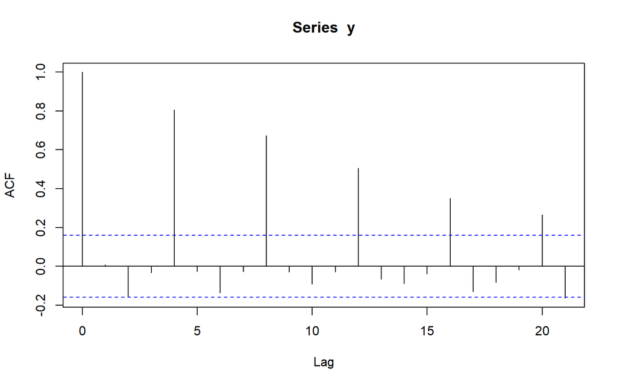

```r
# View the ACF of y
acf(y, plot = TRUE)
```

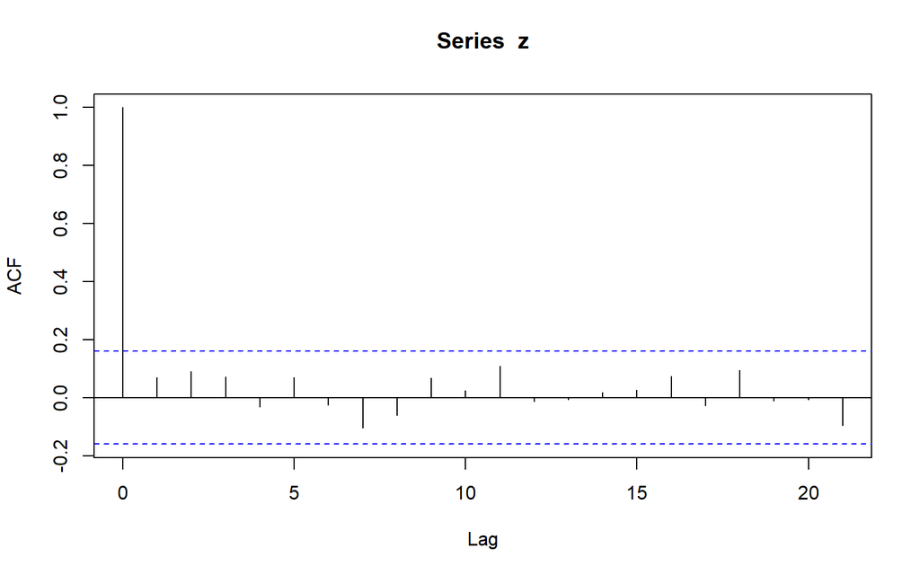

```r
# View the ACF of z
acf(z, plot = TRUE)
```

**Plotting the estimated ACF of x shows large positive correlations for several lags which quickly decay towards zero.**

**Plotting the estimated ACF of y shows large positive correlations at lags which are multiples of four, although these also decay towards zero as the lag multiple increases.**

**Finally, the estimated ACF of z is near zero at all lags. It appears the series z is not linearly related to its past, at least through lag 20.**

# AR intuition

An autoregressive model says:

> **The present depends on the past.**

The coefficient `φ` controls persistence:

- `φ > 0` → persistence
- `φ < 0` → oscillation / anti-persistence
- `φ ≈ 0` → behavior approaches white noise

# Autoregression

# The autoregressive model

The Autoregressive (AR) recursion:

$$Today=Constant+Slope*Yesterday+Noise$$
Mean centered version:

$$(Today-Mean)=Slope*(Yesterday-Mean)+Noise$$
More formally:

$$Y_t - \mu = \phi(Y_{t-1} - \mu) + \epsilon_t$$
Where $\epsilon_t$ s mean zero white noise (WN).

- The mean $\mu$.
- The slope $\phi$.
- The WN variance $\sigma^2$.

**AR processes - I**

$$Y_t - \mu = \phi(Y_{t-1} - \mu) + \epsilon_t$$

- If slope $\phi = 0$ then: $Y_t = \mu + \epsilon_t$ and $Y_t$ is white noise: $(\mu, \sigma^2_{\epsilon})$.
- If slope $\phi \neq 0$, then $Y_t$ depends on both $\epsilon_t$ and $Y_{t-1}$, so the process $Y_t$ is autocorrelated.
- Large values of $\phi$ lead to greater autocorrelation.
- Negative values of $\phi$ result in oscillatory time series.

**AR example**

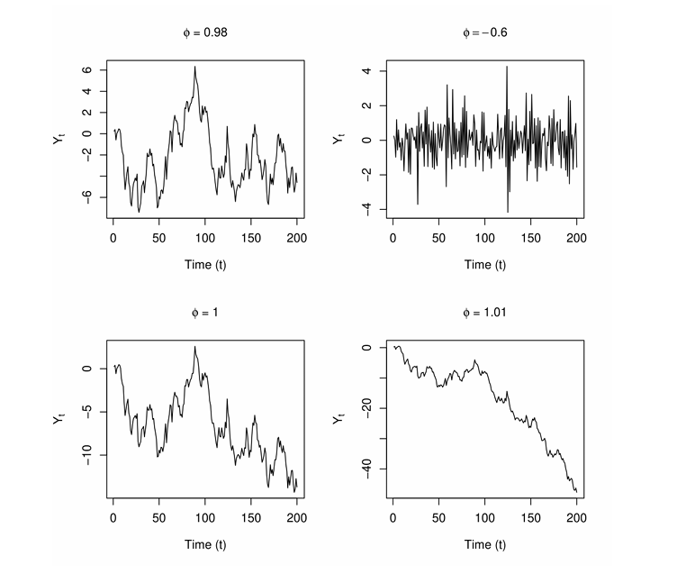

**Autocorrelations**

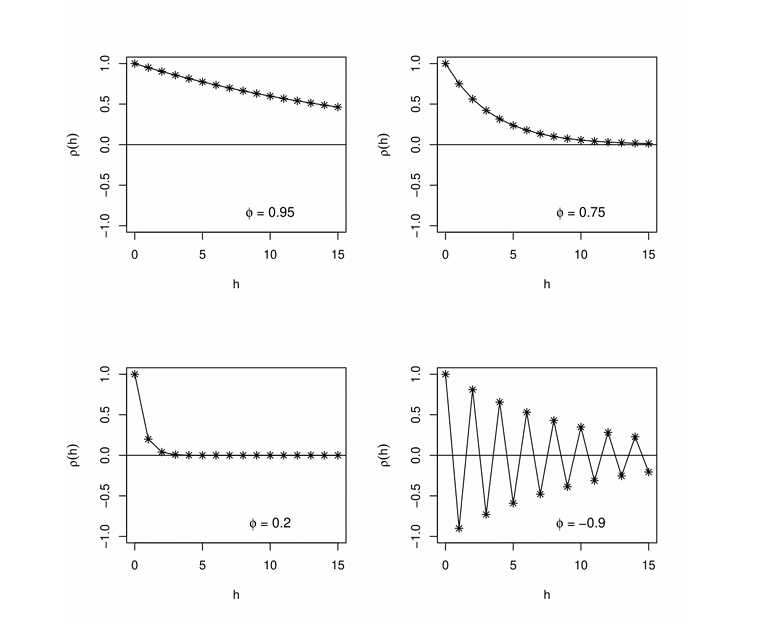

**Random walk**

If $\mu = 0$ and slope $\phi = 1$, then:

$$Y_t = Y_{t-1} + \epsilon_t$$

Which is:

$$Today = Yesterday +Noise$$

But this is a **random walk**.

And $Y_t$ is not stationary in this case.

# Simulate the autoregressive model

The autoregressive (AR) model is arguably the most widely used time series model. It shares the very familiar interpretation of a simple linear regression, but here each observation is regressed on the previous observation. The AR model also includes the white noise (WN) and random walk (RW) models examined in earlier chapters as special cases.

The versatile `arima.sim()` function used in previous chapters can also be used to simulate data from an AR model by setting the `model` argument equal to `list(ar = phi)` , in which `phi` is a slope parameter from the interval (-1, 1). We also need to specify a series length `n`.

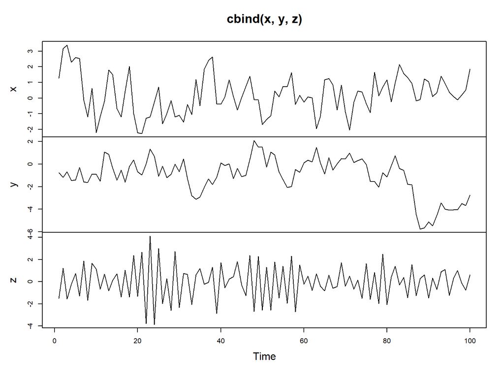

```r
# Simulate an AR model with 0.5 slope
x <- arima.sim(model = list(ar = 0.5), n = 100)

# Simulate an AR model with 0.9 slope
y <- arima.sim(model = list(ar = 0.9), n = 100)

# Simulate an AR model with -0.75 slope
z <- arima.sim(model = list(ar = -0.75), n = 100)

# Plot your simulated data
plot.ts(cbind(x, y, z))
```

**As you can see, your x data shows a just a moderate amount of autocorrelation while your y data shows a large amount of autocorrelation. Alternatively, your z data tends to oscillate considerably from one observation to the next.**

# Estimate the autocorrelation function (ACF) for an autoregression

What if you need to estimate the autocorrelation function from your data? To do so, you’ll need the `acf()` command, which estimates autocorrelation by exploring lags in your data. By default, this command generates a plot of the relationship between the current observation and lags extending backwards.

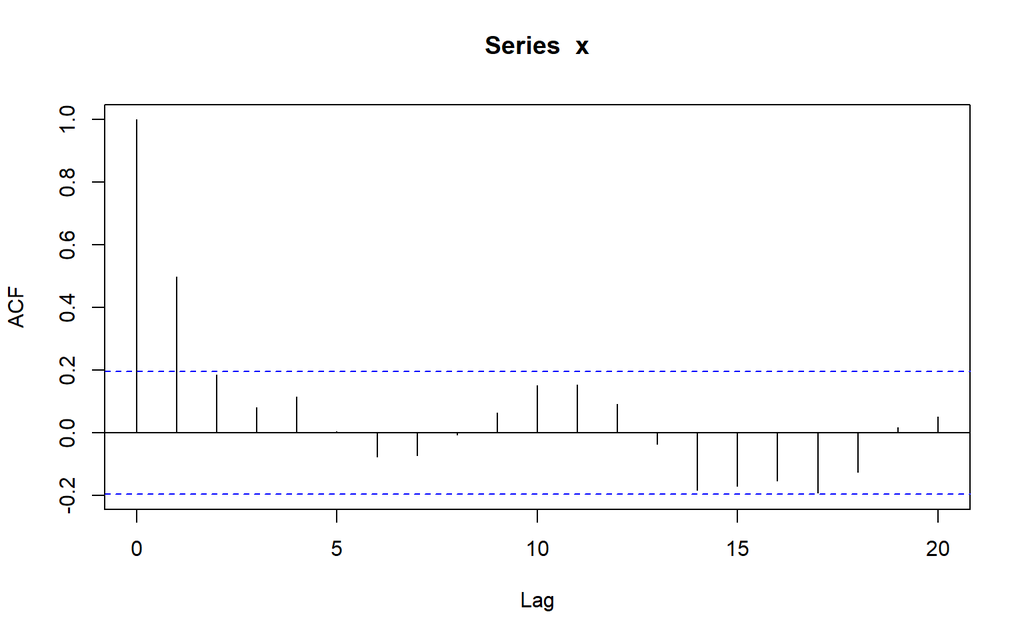

```r
# Calculate the ACF for x
acf(x, plot = TRUE)
```

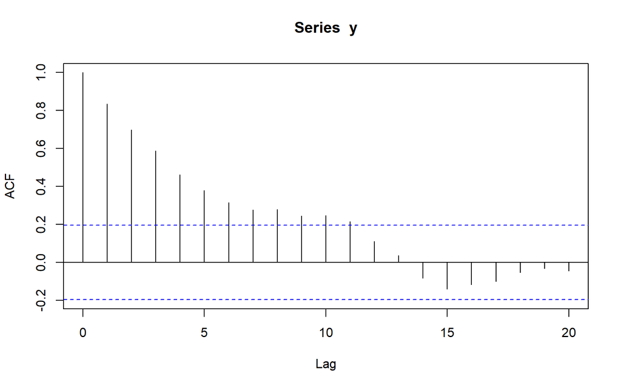

```r
# Calculate the ACF for y
acf(y, plot = TRUE)
```

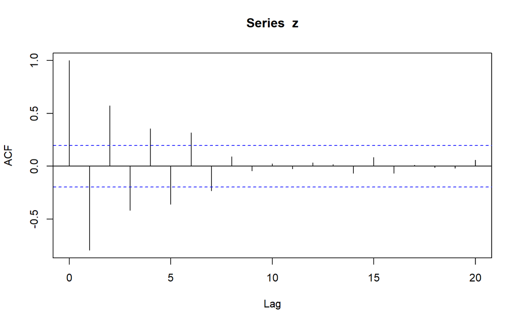

```r
# Calculate the ACF for z

acf(z, plot = TRUE)
```

**The plots generated by the acf() command provide useful information about each lag of your time series. The first series x has positive autocorrelation for the first couple lags, but they quickly approach zero. The second series y has positive autocorrelation for many lags, but they also decay to zero. The last series z has an alternating pattern, as does its autocorrelation function (ACF), but its ACF still quickly decays to zero in magnitude.**

# Persistence and anti-persistence

Autoregressive processes can exhibit varying levels of persistence as well as anti-persistence or oscillatory behavior. Persistence is defined by a high correlation between an observation and its lag, while anti-persistence is defined by a large amount of variation between an observation and its lag.

**The four plots below show varying degrees of persistence and anti-persistence. Which series exhibits the greatest persistence?**

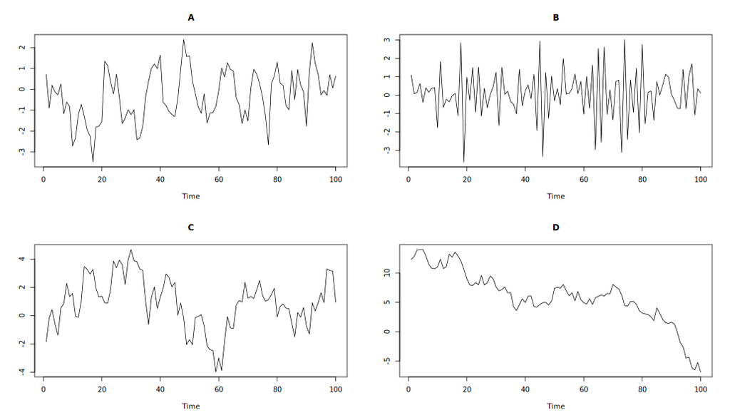

**Answer:** $\checkmark$ D.

# Compare the random walk (RW) and autoregressive (AR) models

The random walk (RW) model is a special case of the autoregressive (AR) model, in which the slope parameter is equal to `1`. Recall from previous chapters that the RW model is not stationary and exhibits very strong persistence. Its sample autocovariance function (ACF) also decays to zero very slowly, meaning past values have a long lasting impact on current values.

The stationary AR model has a slope parameter between -1 and 1. The AR model exhibits higher persistence when its slope parameter is closer to 1, but the process reverts to its mean fairly quickly. Its sample ACF also decays to zero at a quick (geometric) rate, indicating that values far in the past have little impact on future values of the process.

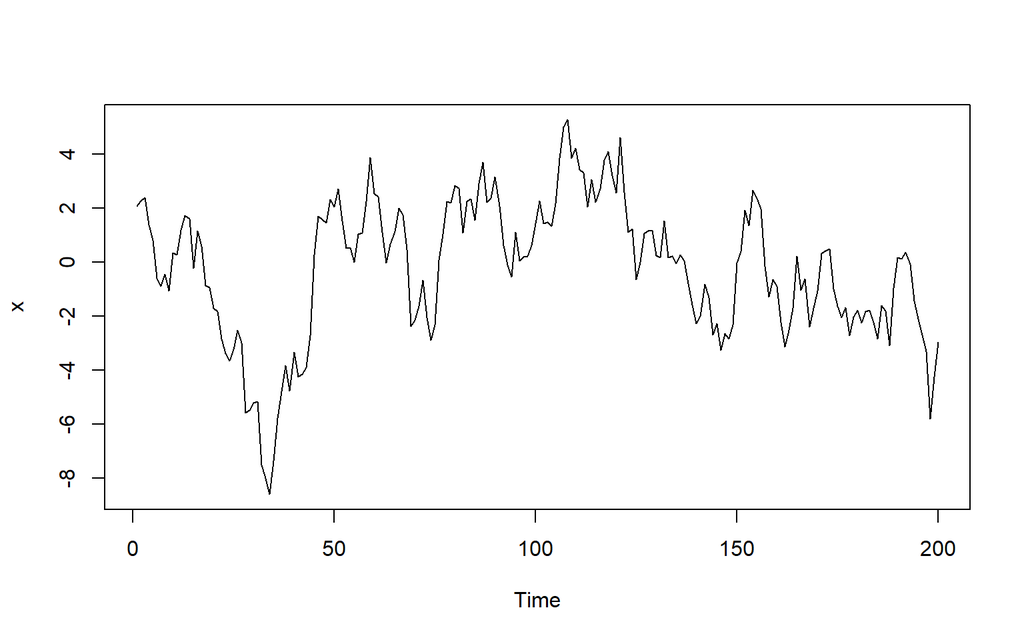

```r
# Simulate and plot AR model with slope 0.9
x <- arima.sim(model = list(ar = 0.9), n = 200)
ts.plot(x)
```

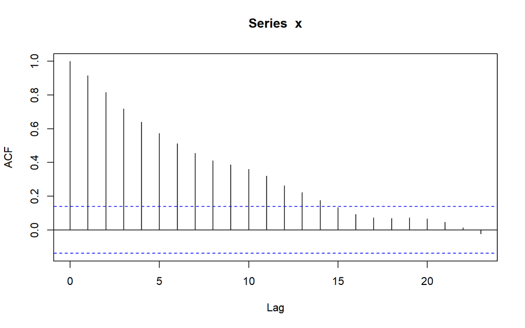

```r
acf(x, plot = TRUE)
```

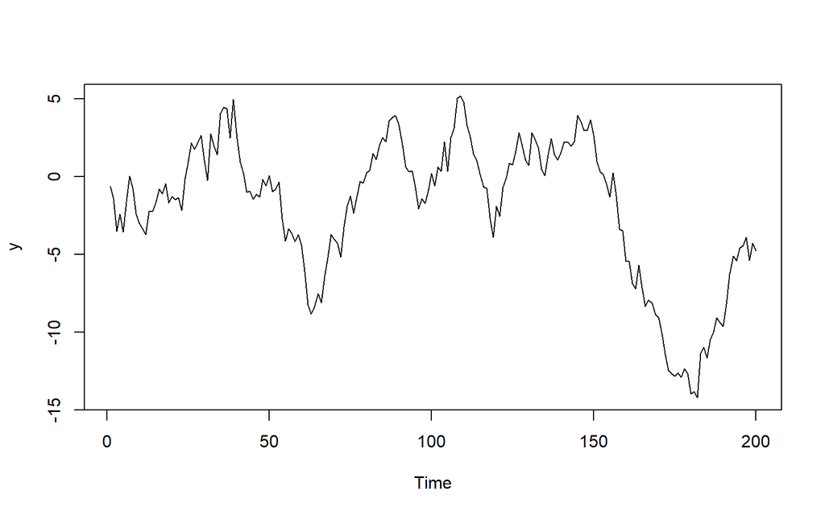

```r
# Simulate and plot AR model with slope 0.98
y <- arima.sim(model = list(ar = 0.98), n = 200)
ts.plot(y)
```

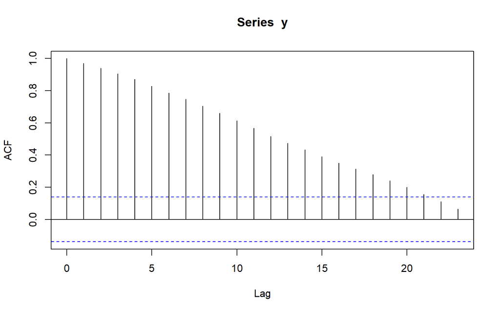

```r
acf(y, plot = TRUE)
```

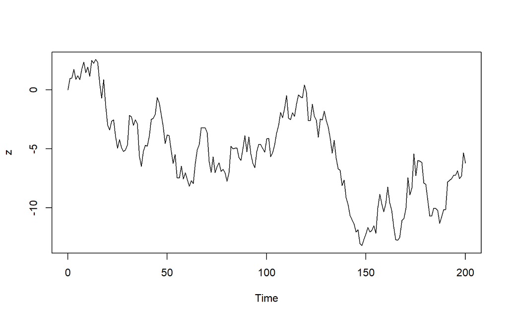

```r
# Simulate and plot RW model
z <- arima.sim(model = list(order = c(0, 1, 0)), n = 200)
ts.plot(z)
```

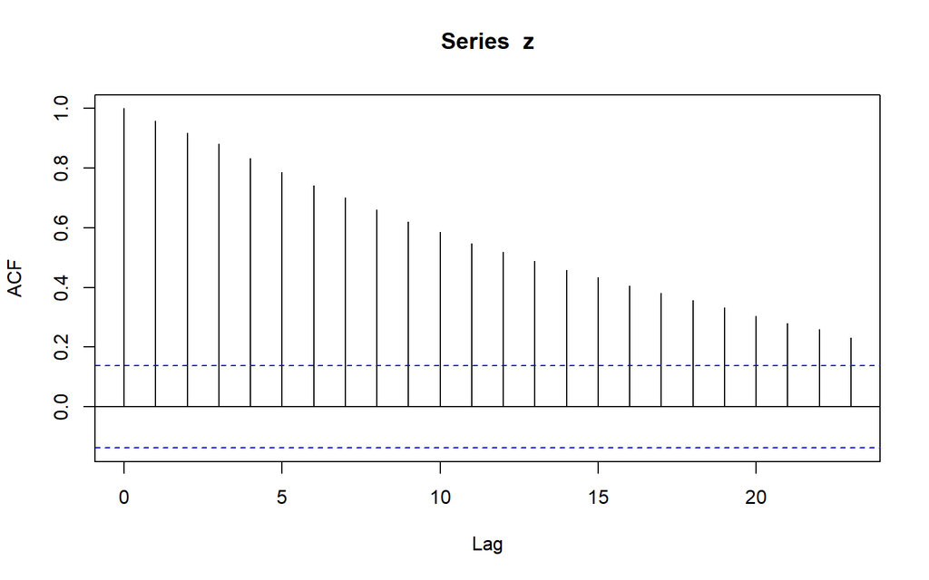

```r
acf(z)
```

# AR model estimation and forecasting

**AR processes: fitted values**

- AR fitted values:

$$\hat{Y_t} = \hat{\mu} + \hat{\phi}(Y_{t-1} - \hat{\mu})$$

- Residuals:

$$\hat{\epsilon_t} = Y_t - \hat{Y_t}$$

- Fitted value

$$\hat{Y_t} = Y_t - \hat{\epsilon_t}$$

### Estimate the autoregressive (AR) model

For a given time series `x` we can fit the autoregressive (AR) model using the `arima()` command and setting order equal to `c(1, 0, 0)`. Note for reference that an AR model is an **ARIMA(1, 0, 0)** model.

In this exercise, you’ll explore additional qualities of the AR model by practicing the `arima()` command on a simulated time series `x` as well as the `AirPassengers` data. This command allows you to identify the estimated slope (`ar1`), mean (`intercept`), and innovation variance (`sigma^2`) of the model.

```r
# Fit the AR model to x
arima(x, order = c(1, 0, 0))
```

```
##
## Call:
## arima(x = x, order = c(1, 0, 0))
##
## Coefficients:
##          ar1  intercept
##       0.9195    -0.2819
## s.e.  0.0271     0.8404
##
## sigma^2 estimated as 1.019:  log likelihood = -286.59,  aic = 579.19
```

```r
# Fit the AR model to AirPassengers
AR <- arima(AirPassengers, order = c(1, 0, 0))
print(AR)
```

```
##
## Call:
## arima(x = AirPassengers, order = c(1, 0, 0))
##
## Coefficients:
##          ar1  intercept
##       0.9646   278.4649
## s.e.  0.0214    67.1141
##
## sigma^2 estimated as 1119:  log likelihood = -711.09,  aic = 1428.18
```

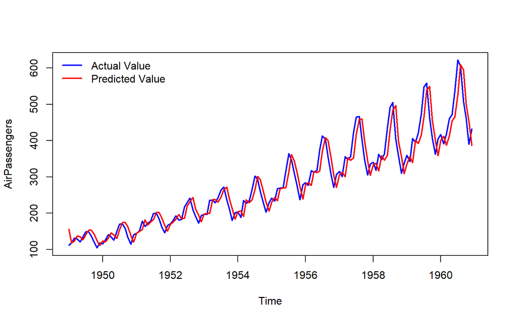

```r
# Run the following commands to plot the series and fitted values

ts.plot(AirPassengers, col = "blue", lwd = 2)
AR_fitted <- AirPassengers - residuals(AR)
points(AR_fitted, type = "l", col = "red", lty = 1, lwd = 2)

labels <- c("Actual Value", "Predicted Value")
colors <- c("blue", "red")

legend("topleft", labels, col = colors, lty = 1, lwd = 2, bty = "n")
```

*By fitting an AR model to the AirPassengers data, you’ve succesfully modeled the data in a reproducible fashion. This allows you to predict future observations based on your AR_fitted data.*

### Simple forecasts from an estimated AR model

Now that you’ve modeled your data using the `arima()` command, you are ready to make simple forecasts based on your model. The `predict()` function can be used to make forecasts from an estimated AR model. In the object generated by your predict() command, the `$pred` value is the forecast, and the `$se` value is the standard error for the forecast.

To make predictions for several periods beyond the last observations, you can use the n.ahead argument in your `predict()` command. This argument establishes the forecast horizon (h), or the number of periods being forecast. The forecasts are made recursively from 1 to h-steps ahead from the end of the observed time series.

In this exercise, you’ll make simple forecasts using an AR model applied to the `Nile` data, which records annual observations of the flow of the River Nile from 1871 to 1970.

```r
# Fit an AR model to Nile
AR_fit <- arima(Nile, order  = c(1, 0, 0))
print(AR_fit)
```

```
##
## Call:
## arima(x = Nile, order = c(1, 0, 0))
##
## Coefficients:
##          ar1  intercept
##       0.5063   919.5685
## s.e.  0.0867    29.1410
##
## sigma^2 estimated as 21125:  log likelihood = -639.95,  aic = 1285.9
```

```r
# Use predict() to make a 1-step forecast
predict_AR <- predict(AR_fit)

# Obtain the 1-step forecast using $pred[1]
predict_AR$pred[1]
```

```
## [1] 828.6576
```

```r
# Use predict to make 1-step through 10-step forecasts
predict(AR_fit, n.ahead = 10)
```

```
## $pred
## Time Series:
## Start = 1971
## End = 1980
## Frequency = 1
##  [1] 828.6576 873.5426 896.2668 907.7715 913.5960 916.5448 918.0377 918.7935
##  [9] 919.1762 919.3699
##
## $se
## Time Series:
## Start = 1971
## End = 1980
## Frequency = 1
##  [1] 145.3439 162.9092 167.1145 168.1754 168.4463 168.5156 168.5334 168.5380
##  [9] 168.5391 168.5394
```

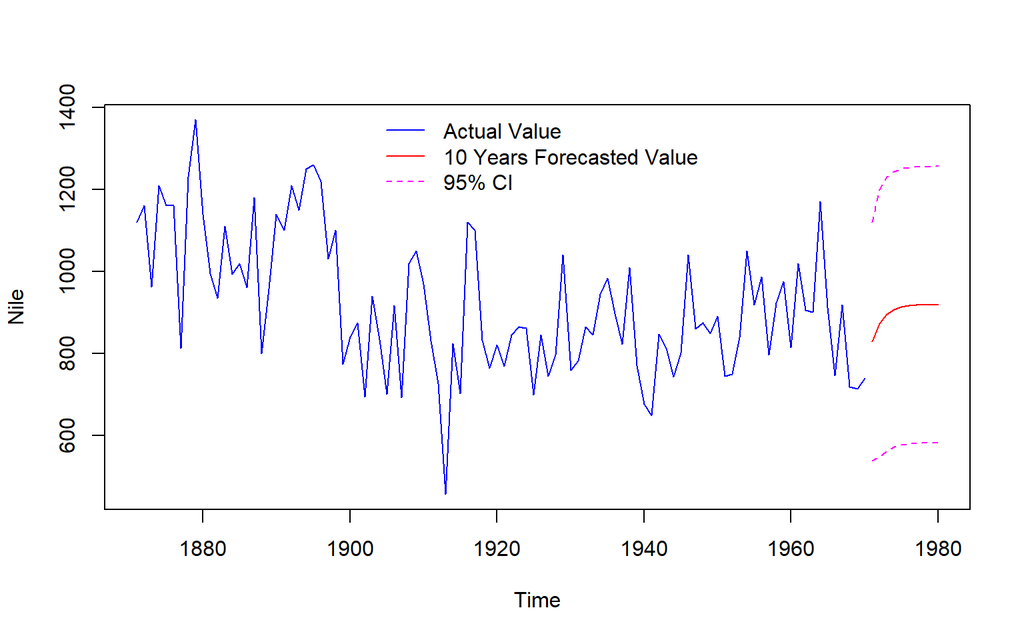

```r
# Run to plot the Nile series plus the forecast and 95% prediction intervals
ts.plot(Nile, xlim = c(1871, 1980), col = "blue")
AR_forecast <- predict(AR_fit, n.ahead = 10)$pred
AR_forecast_se <- predict(AR_fit, n.ahead = 10)$se
points(AR_forecast, type = "l", col = "red")
points(AR_forecast - 2*AR_forecast_se, type = "l", col = "magenta", lty = 2)
points(AR_forecast + 2*AR_forecast_se, type = "l", col = "magenta", lty = 2)

labels <- c("Actual Value", "10 Years Forecasted Value", "95% CI")

colors <- c("blue", "red", "magenta")

legend("top", labels, col = colors, lty = c(1, 1, 2), bty = "n")
```

Your predictions of River Nile flow from 1971 to 1980 make sense based on the data you have. The relatively wide band of confidence (represented by the dotted lines) is a result of the low persistence in your `Nile` data.

# MA intuition

A moving-average model says:

> **The present depends on current and recent shocks.**

Unlike an AR model, the MA model is built around **white-noise innovations** rather than lagged observations of the series itself.

# A Simple Moving Average Model

The simple moving average (MA) model:

$$Today = Mean + Noise +Slope * (Yesterday's \; Noise)$$
More formally:

$$Y_t = \mu + \epsilon_t + \theta \epsilon_{t-1}$$

where $\epsilon_t$ is mean zero white noise (WN).

Three parameters:

- The mean $\mu$
- The slope $\theta$
- The WN variance $\sigma^2$
- If slope $\theta$ is zero then:

$$Y_t = \mu + \epsilon_t$$

And $Y_t$ is White Noise $(\mu, \sigma^2_{\epsilon})$

- If slope $\theta$ is not zero then $Y_t$ depends on both $\epsilon_t$ and $\epsilon_{t-1}$

And the process $Y_t$ is autocorrelated

- Large values of $\theta$ lead to greater autocorrelation
- Negative values of $\theta$ result in oscillatory time series

**MA examples**

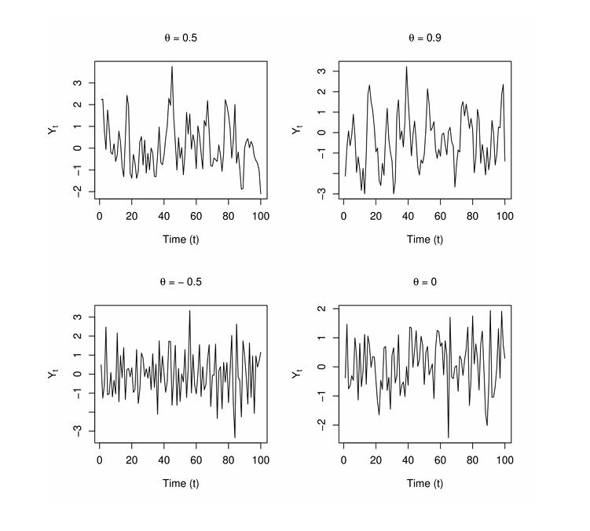

**Autocorrelations**

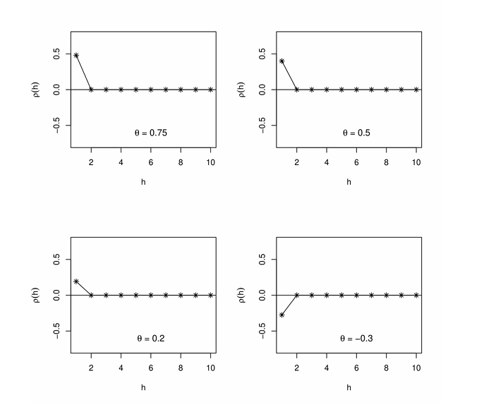

*Only lag 1 autocorrelation non-zero for the MA model.*

# Simulate the simple moving average model

The simple moving average (MA) model is a parsimonious time series model used to account for very short-run autocorrelation. It does have a regression like form, but here each observation is regressed on the previous innovation, which is not actually observed. Like the autoregressive (AR) model, the MA model includes the white noise (WN) model as special case.

As with previous models, the MA model can be simulated using the `arima.sim()` command by setting the `model` argument to `list(ma = theta)`, where theta is a slope parameter from the interval (-1, 1). Once again, you also need to specify the series length using the `n` argument.

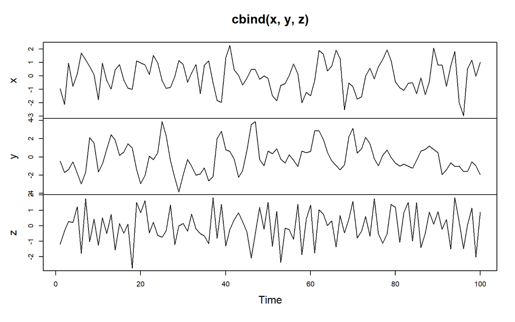

```r
# Generate MA model with slope 0.5
x <- arima.sim(model = list(ma = 0.5), n = 100)

# Generate MA model with slope 0.9
y <- arima.sim(model = list(ma = 0.9), n = 100)

# Generate MA model with slope -0.5
z <- arima.sim(model = list(ma = -0.5), n = 100)

# Plot all three models together
plot.ts(cbind(x, y, z), col = 1:3)
```

Note that there is some very short-run persistence for the positive slope values (`x` and `y`), and the series has a tendency to alternate when the slope value is negative (`z`).

# Estimate the autocorrelation function (ACF) for a moving average

Now that you’ve simulated some MA data using the `arima.sim()` command, you may want to estimate the autocorrelation functions (ACF) for your data. As in the previous chapter, you can use the `acf()` command to generate plots of the autocorrelation in your MA data.

In this exercise, you’ll use `acf()` to estimate the ACF for three simulated MA series, `x`, `y`, and `z`. These series have slope parameters of 0.4, 0.9, and -0.75, respectively, and are shown in the figure on the right.

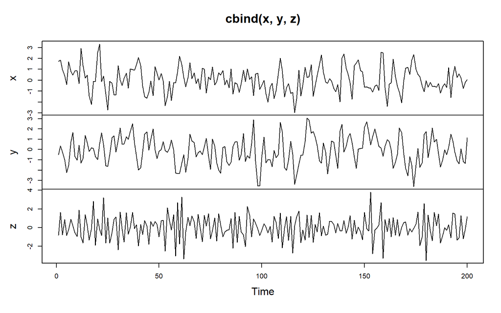

```r
x <- arima.sim(model = list(ma = 0.4), n = 200)

# Generate MA model with slope 0.9
y <- arima.sim(model = list(ma = 0.9), n = 200)

# Generate MA model with slope -0.5
z <- arima.sim(model = list(ma = -0.75), n = 200)

# Plot all three models together
plot.ts(cbind(x, y, z), col = 1:3)
```

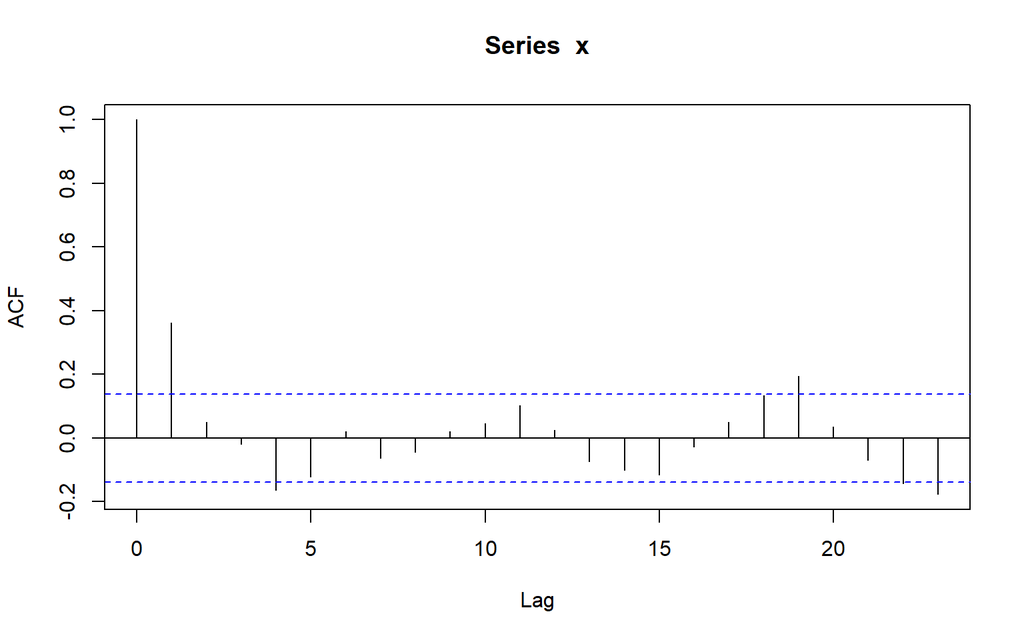

```r
# Calculate ACF for x
acf(x, plot = TRUE)
```

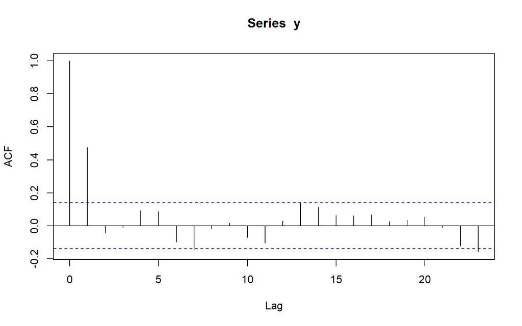

```r
# Calculate ACF for y
acf(y, plot = TRUE)
```

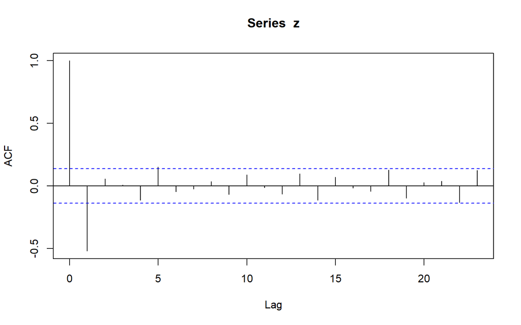

```r
# Calculate ACF for z
acf(z, plot = TRUE)
```

As you can see from your ACF plots, the series `x` has positive sample autocorrelation at the first lag, but it is approximately zero at other lags. The series `y` has a larger sample autocorrelation at its first lag, but it is also approximately zero for the others. The series `z` has an alternating pattern, and its sample autocorrelation is negative at the first lag. However, similar to the others, it is approximately zero for all higher lags.

# MA model estimation and forecasting

- MA fitted values:

$$\begin{aligned}
\widehat{Today} &= \widehat{Mean} +
\widehat{Slope}\times\widehat{Yesterday's \; Noise} \\[6pt]
\hat{Y}_t &= \hat{\mu} + \hat{\theta}\hat{\epsilon}_{t-1}
\end{aligned}$$

- Rsiduals

$$\hat{\epsilon_t} = Y_t - \hat{Y_t}$$

# Estimate the simple moving average model

Now that you’ve simulated some MA models and calculated the ACF from these models, your next step is to fit the simple moving average (MA) model to some data using the `arima()` command. For a given time series `x` we can fit the simple moving average (MA) model using `arima(..., order = c(0, 0, 1))`. Note for reference that an MA model is an **ARIMA(0, 0, 1)** model.

```r
x <- c(
  -0.29104202,  0.37763081, -0.41268279,  0.79060856,  2.62597032,
   1.95541100,  1.32147721, -0.56276017, -1.00480197, -1.94491932,
  -1.30029115, -0.96819303, -1.62074777, -0.24723380, -0.91119582,
  -0.03614666,  0.20326806,  0.32343468,  1.03223134, -0.06602086,
   1.10417816,  3.57665937,  1.92456285,  0.25506223,  0.09188144,
   0.83193435,  0.57777123, -1.18909258, -0.92723871, -0.28826927,
   0.09173721, -0.24812302, -1.73867120,  0.59943768,  1.40413384,
   1.94216369,  2.00154846,  2.47319616,  2.00534596, -0.54680647,
  -0.08531535,  0.05460297,  1.08002979,  0.09135667,  0.03767858,
   1.06184834, -0.57062663, -0.14874580, -0.29691240, -2.91564128,
  -0.89162136,  0.06409581, -1.89441014, -0.82051653,  0.29616018,
   1.24526044,  2.07560937,  0.81950605, -0.44521801, -0.61898486,
  -0.30817850, -0.77920197, -0.61910425,  0.54089324,  0.31254753,
  -0.41565724, -0.63745705, -1.19774636,  0.38173220,  0.01097415,
  -0.55027499,  0.27150915, -1.32344173, -1.86513516, -1.99571623,
   0.09053037, -1.31823319, -1.26874080,  0.25936070,  0.98662057,
   1.74593866,  1.88010691,  0.43493006, -0.98614375,  0.22889483,
   1.78095941,  3.71337005,  2.01759428, -0.46069542, -1.42215110,
  -0.60412149,  1.40543362,  2.35852554,  1.90795579,  2.05187460,
   1.57197343, -0.75491260, -1.39643096, -0.52225049, -0.29842969
)

arima(x, order = c(0, 0, 1))
```

```
##
## Call:
## arima(x = x, order = c(0, 0, 1))
##
## Coefficients:
##          ma1  intercept
##       0.7928     0.1589
## s.e.  0.0902     0.1747
##
## sigma^2 estimated as 0.9576:  log likelihood = -140.22,  aic = 286.44
```

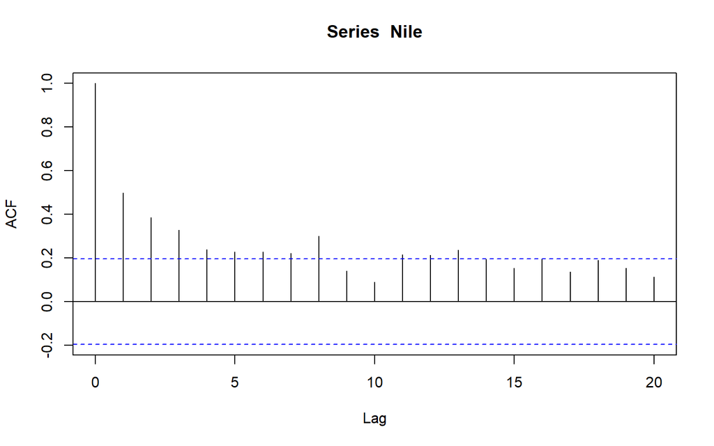

```r
#ACF plot of Nile

acf(Nile, plot = T)
```

```r
# Fit the MA model to Nile
MA <- arima(Nile, order = c(0, 0, 1))
print(MA)
```

```
##
## Call:
## arima(x = Nile, order = c(0, 0, 1))
##
## Coefficients:
##          ma1  intercept
##       0.3783   919.2433
## s.e.  0.0791    20.9685
##
## sigma^2 estimated as 23272:  log likelihood = -644.72,  aic = 1295.44
```

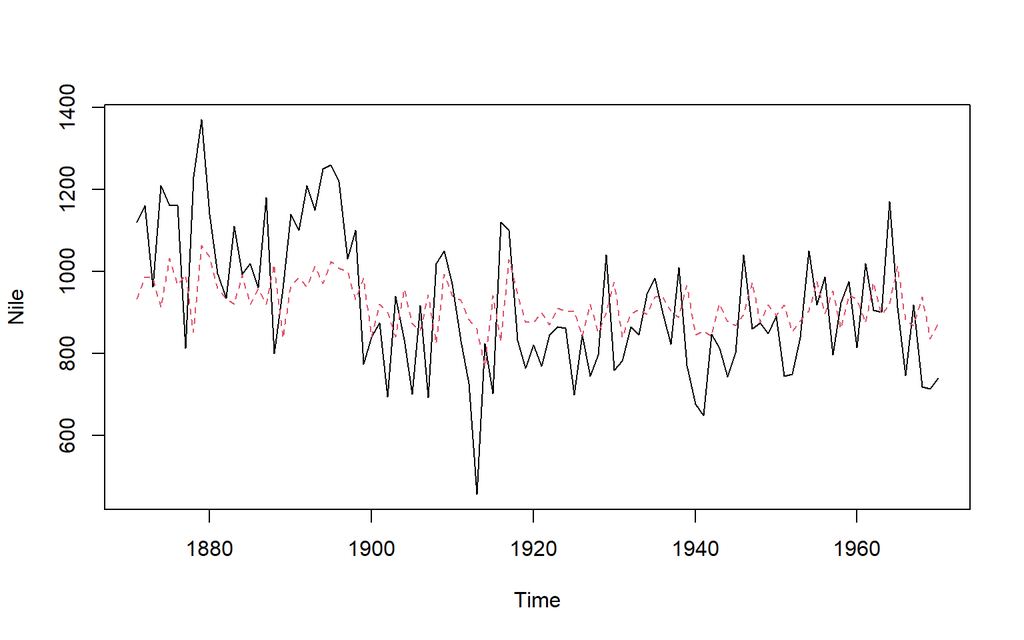

```r
# Plot Nile and MA_fit
ts.plot(Nile)
MA_fit <- Nile - resid(MA)
points(MA_fit, type = "l", col = 2, lty = 2)
```

By fitting an MA model to your Nile data, you’re able to capture variation in the data for future prediction.

*Based on the plot you’ve generated, does the MA model appear to be a strong fit for the Nile data?*

**Answer:** No, the MA model does not appear to be a particularly strong fit for the Nile data.

# Simple forecasts from an estimated MA model

Now that you’ve estimated a MA model with your `Nile` data, the next step is to do some simple forecasting with your model. As with other types of models, you can use the `predict()` function to make simple forecasts from your estimated MA model. Recall that the `$pred` value is the forecast, while the `$se` value is a standard error for that forecast, each of which is based on the fitted MA model.

Once again, to make predictions for several periods beyond the last observation you can use the `n.ahead = h` argument in your call to `predict()`. The forecasts are made recursively from 1 to h-steps ahead from the end of the observed time series. However, note that except for the 1-step forecast, all forecasts from the MA model are equal to the estimated mean (`intercept`).

In this exercise, you’ll use the `MA` model derived from your `Nile` data to make simple forecasts about future River Nile flow levels. Your `MA` model from the previous exercise is available in your environment.

```r
# Make a 1-step forecast based on MA
predict_MA <-predict( MA)

# Obtain the 1-step forecast using $pred[1]
predict_MA$pred[1]
```

```
## [1] 868.8747
```

```r
# Make a 1-step through 10-step forecast based on MA
predict(MA, n.ahead = 10)
```

```
## $pred
## Time Series:
## Start = 1971
## End = 1980
## Frequency = 1
##  [1] 868.8747 919.2433 919.2433 919.2433 919.2433 919.2433 919.2433 919.2433
##  [9] 919.2433 919.2433
##
## $se
## Time Series:
## Start = 1971
## End = 1980
## Frequency = 1
##  [1] 152.5508 163.1006 163.1006 163.1006 163.1006 163.1006 163.1006 163.1006
##  [9] 163.1006 163.1006
```

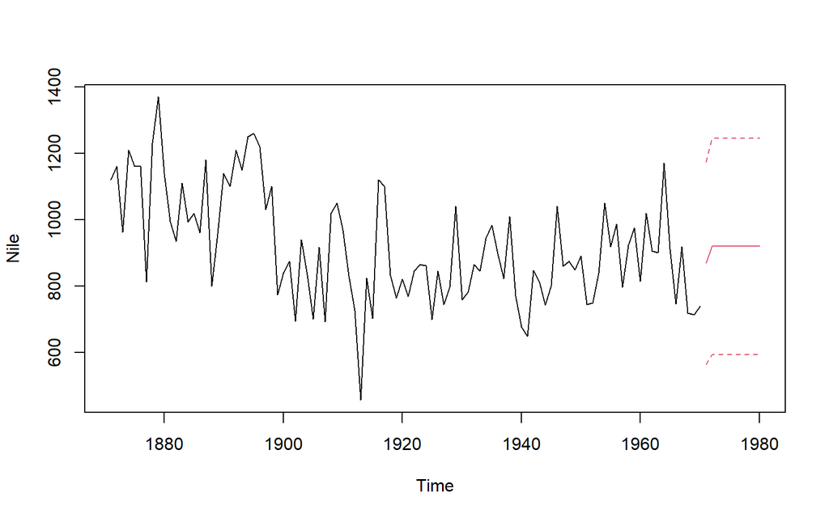

```r
# Plot the Nile series plus the forecast and 95% prediction intervals
ts.plot(Nile, xlim = c(1871, 1980))
MA_forecasts <- predict(MA, n.ahead = 10)$pred
MA_forecast_se <- predict(MA, n.ahead = 10)$se
points(MA_forecasts, type = "l", col = 2)
points(MA_forecasts - 2*MA_forecast_se, type = "l", col = 2, lty = 2)
points(MA_forecasts + 2*MA_forecast_se, type = "l", col = 2, lty = 2)
```

Note that the MA model can only produce a 1-step forecast. For additional forecasting periods, the `predict()` command simply extends the original 1-step forecast. This explains the unexpected horizontal lines after 1971.

# Model-selection mindset

Do not choose AR or MA only because one plot “looks better.”

Consider:

- ACF/PACF behavior
- residual diagnostics
- AIC
- BIC
- forecasting performance
- interpretability

# Compare AR and MA models

# AR vs MA models

As you’ve seen, autoregressive (AR) and simple moving average (MA) are two useful approaches to modeling time series. But how can you determine whether an AR or MA model is more appropriate in practice?

To determine model fit, you can measure the Akaike information criterion (AIC) and Bayesian information criterion (BIC) for each model. While the math underlying the AIC and BIC is beyond the scope of this course, for your purposes the main idea is these these indicators penalize models with more estimated parameters, to avoid overfitting, and smaller values are preferred. All factors being equal, a model that produces a lower AIC or BIC than another model is considered a better fit.

To estimate these indicators, you can use the `AIC()` and `BIC()` commands, both of which require a single argument to specify the model in question.

In this exercise, you’ll return to the `Nile` data and the `AR` and `MA` models you fitted to this data. These models and their predictions for the 1970s (`AR_fit`) and (`MA_fit`) are depicted in the plot on the right.

```r
AR <- arima(Nile, order = c(1, 0, 0))

AR_fit <- Nile - residuals(AR)

MA <- arima(Nile, order = c(0, 0, 1))

MA_fit <- Nile - residuals(MA)
```

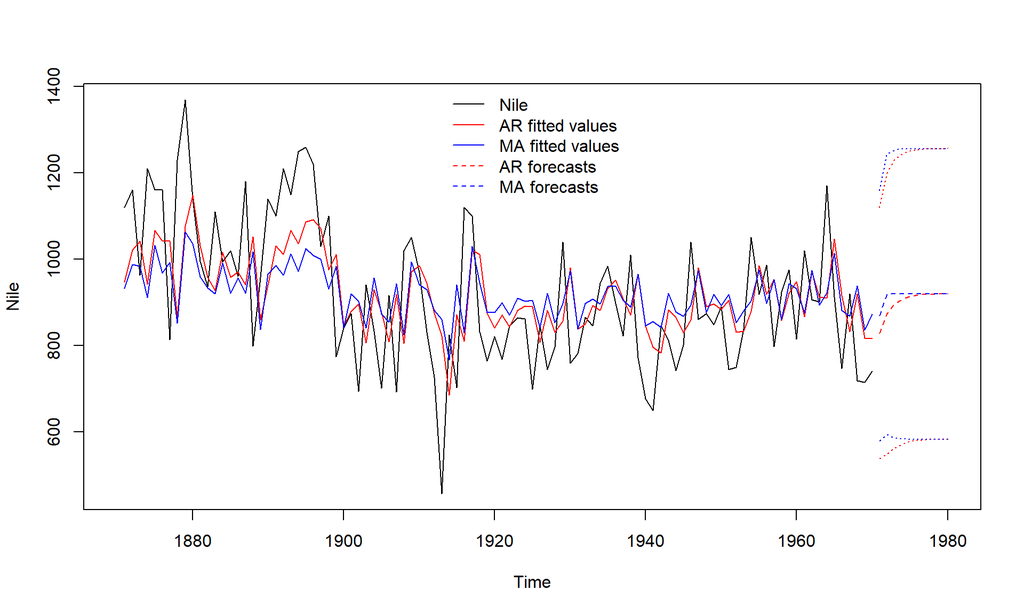

```r
ts.plot(Nile, xlim = c(1870, 1980))
points(AR_fit, col = "red", type = "l")
points(MA_fit, col = "blue", type = "l")

AR_forecast <- predict(AR, n.ahead = 10)$pred
AR_forecast_se <- predict(AR, n.ahead = 10)$se

points(AR_forecast, type = "l", col = "red", lty = 2)
points(AR_forecast - 2*AR_forecast_se, type = "l", col = "red", lty = 3)
points(AR_forecast + 2*AR_forecast_se, type = "l", col = "red", lty = 3)

MA_forecast <- predict(MA, n.ahead = 10)$pred
MA_forecast_se <- predict(MA, n.ahead = 10)$se

points(MA_forecast, type = "l", col = "blue", lty = 2)
points(MA_forecast - 2*AR_forecast_se, type = "l", col = "blue", lty = 3)
points(MA_forecast + 2*AR_forecast_se, type = "l", col = "blue", lty = 3)

labels <- c("Nile", "AR fitted values", "MA fitted values", "AR forecasts", "MA forecasts")

colors <- c("black", "red", "blue", "red", "blue")

legend("top", labels, col = colors, lty = c(1, 1, 1, 2, 2), bty = "n")
```

```r
# Find correlation between AR_fit and MA_fit
cor(AR_fit, MA_fit)
```

```
## [1] 0.9401765
```

```r
# Find AIC of AR
AIC(AR)
```

```
## [1] 1285.904
```

```r
# Find AIC of MA
AIC(MA)
```

```
## [1] 1295.442
```

```r
# Find BIC of AR
BIC(AR)
```

```
## [1] 1293.72
```

```r
# Find BIC of MA
BIC(MA)
```

```
## [1] 1303.257
```

Although the predictions from both models are very similar (indeed, they have a correlation coeffiicent of 0.94), both the AIC and BIC indicate that the AR model is a slightly better fit for your `Nile` data.

# Name that model by time series plot

Now that you’ve simulated, fitted, and generated forecasts based on several models, you should have a good idea of what each model looks like and where it is most useful.

A time series from each of the four models we have considered in this course was simulated and they are shown in one of the four panels in the plot on the right. They include the white noise (WN), random walk (RW), autoregressive (AR), and simple moving average (MA) models.

Match each time series plot with one of our models WN, RW, AR, MA.

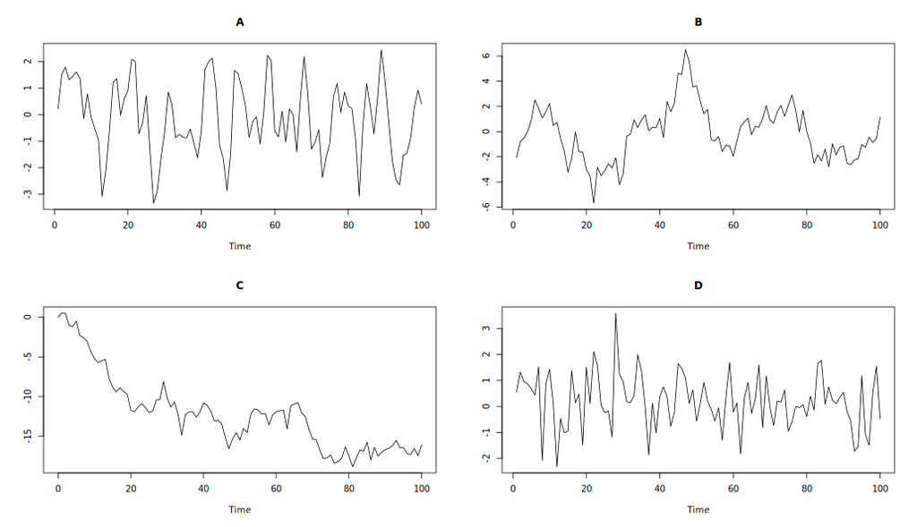

**Answer:** $\checkmark$ (A) MA, (B) AR, (C) RW, (D) WN

Series A shows short-run dependence but reverts quickly to the mean, so it must be the MA model. Series B and C are consistent with AR and RW, respectively. Series D does not show any clear patterns, so it must be the WN model.

# Name that model by ACF plot

Finally, the ACF plot for each model provides additional useful information about how each model operates (and, therefore, when you should use each model). It is also helpful to be able to identify the model based on the ACF plot.

A time series from each of the four models you have considered in this course was simulated and their sample autocorrelation functions (ACF) are shown in one of the four panels in the adjoining figure. They include the white noise (WN), random walk (RW), autoregressive (AR), and simple moving average (MA) models.

Match each sample ACF plot with one of our models WN, RW, AR, MA.

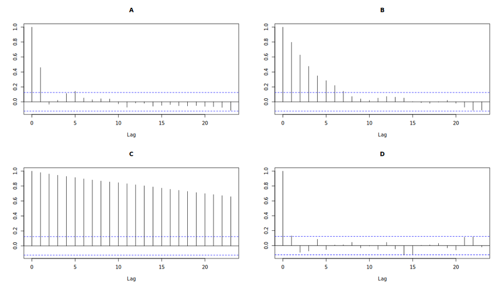

**Answer:** $\checkmark$ (A) MA, (B) AR, (C) RW, (D) WN

# Final revision

# Time series cheat sheet

| Concept | Core idea | Typical R command |
| --- | --- | --- |
| Time index | When observations occur | `time()` |
| Frequency | Observations per unit time | `frequency()` |
| Time-series object | Stores values + time attributes | `ts()` |
| Log transformation | Stabilizes multiplicative variability | `log()` |
| First difference | Change from one period to the next | `diff(x)` |
| Seasonal difference | Change across a seasonal lag | `diff(x, lag = s)` |
| White noise | No serial dependence | `arima(x, order=c(0,0,0))` |
| Random walk | Integrated white noise | `diff(x)` |
| Correlation | Association between variables | `cor()` |
| ACF | Association with past values | `acf()` |
| AR model | Depends on lagged observations | `arima()` |
| MA model | Depends on lagged shocks | `arima()` |
| Forecast | Predict future observations | `predict()` |
| Model comparison | Penalized fit criteria | `AIC()`, `BIC()` |

# Self-check quiz

**1. Which process is stationary?**

A. Random walk  
B. Random walk with drift  
C. White noise  
D. A series with a deterministic trend

**Answer:** C

**2. What does `diff(x)` calculate by default?**

The first difference:

$$\Delta x_t = x_t - x_{t-1}$$

**3. What does a large positive lag-1 ACF suggest?**

Strong positive persistence: large values tend to be followed by large values, and small values by small values.

**4. What is the main purpose of differencing?**

To remove a changing level/trend or seasonal component so that the remaining series is easier to model.

**5. What is the key difference between AR and MA models?**

AR models use **past observations**; MA models use **current and past innovations/shocks**.

# Final workflow

```
Raw series
   ↓
Plot + inspect
   ↓
Check trend / seasonality / variability
   ↓
Transform if needed
   ↓
Check stationarity
   ↓
Inspect ACF
   ↓
Fit candidate AR / MA models
   ↓
Check residuals
   ↓
Compare AIC / BIC
   ↓
Forecast
```

> **Golden rule:** A good time-series model should capture meaningful dependence in the data while leaving residuals that behave approximately like white noise.

# End of presentation

**Key message:**  
Time series analysis is not just about fitting a model. It is about understanding **how observations evolve through time**, removing systematic structure when appropriate, modeling the remaining dependence, and validating the model before forecasting.